```python
from IPython.display import Image
%matplotlib inline
```

# Logistic Regression

## Mô hình hóa xác suất thông qua logistic regression

Mặc dù perceptron rule thường dùng để giới thiệu về thuật toán phân loại trong Machine Learning. Tuy nhiên, hạn chế lớn nhất của nó là sẽ không bao giờ hội tụ nếu dữ liễu các lớp không linearly separable.

Để giải quyết vấn đề này, có môt thuật toán đơn giản, mạnh mẽ hơn là Logistic Regression

Sự khác nhau giữa Adaline và Logistic regression được thể hiện như dưới đây:

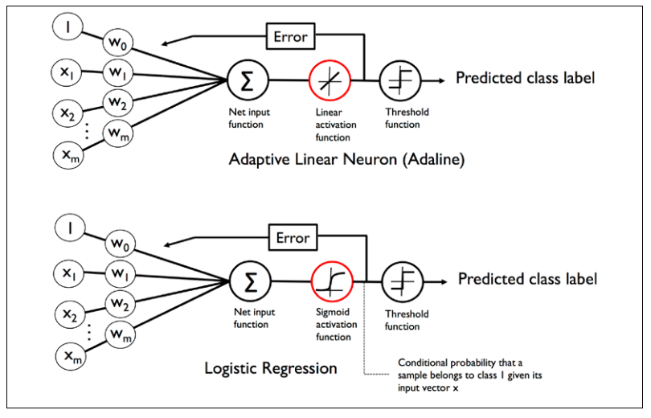

```python
Image(filename='adaline_vs_logisticregression.png')
```

Trong thực tế, logistic regression không chỉ ứng dụng trong dự đoán nhãn mà còn dùng để dự đoán xác suất xảy ra của một vấn đề cụ thể. Trong dự báo thời tiết, logistic regression không chỉ dự đoán một ngày trong tương lai có mưa hay không, mà còn dự đoán được xác suất xảy ra mưa. Tương tự, hồi quy logistic có thể được sử dụng để dự đoán khả năng bệnh nhân mắc một bệnh cụ thể với các triệu chứng nhất định, đó là lý do tại sao hồi quy logistic rất phổ biến trong lĩnh vực y học.

## Ví dụ:

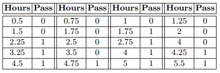

```python
Image(filename='VD.png')
```

Xét một ví dụ về sự liên quan giữa thời gian ôn thi và kêt quả thi của 20 sinh viên được cho trong bảng trên. Bài toán đặt là là xây dựng mô hình để đánh giá khả năng thi đậu của một sinh viên dựa trên thời gian ôn thi

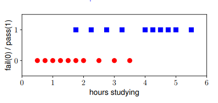

```python
Image(filename='VD2.png')
```

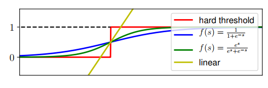

```python
Image(filename='VD3.png')
```

Nhìn chung thời gian học càng nhiều thì khả năng thi đỗ càng cao. Tuy nhiên, không có một ngưỡng nào đó để khẳng định mọi sinh viên dành thời gian học nhiều một ngưỡng nào đó chắc chắn sẽ thi đậu. Nói cách khác dữ liệu của 2 lớp ở trên không linear separable. Vì vậy nếu dùng Adaline sẽ không phù hợp, thay vì dự đoán chính xác có thi đậu hay không thì ta có thể dự đoán xác suất để một sinh viên thi đậu là bao nhiêu dựa trên thời gian ôn thi

## Activation function

Trong logistic regression, chúng ta cần ước lượng giá trị p - xác suất một vấn đề xảy ra có giá trị trong từ 0 -> 1, với đầu vào là kết quả của hàm *net input* có giá trị từ $-\infty$ -> $+\infty$. Do đó chúng ta cần một hàm để chuyển đổi giữa hai giá trị này.

Ta có công thức của Odds như sau:

Odds: $\frac{p}{1-p} = \frac{\frac{C_positive}{n}}{\frac{C_nagative}{n}} = \frac{C_positive}{C_nagative}$

Logit: $\ln{\frac{p}{1-p}}$

Hàm logit nhận giá trị đầu vào trong (0, 1) và biến đổi chúng thành các giá trị trên toàn bộ phạm vi số thực $(-\infty, \infty)$, mà chúng ta có thể sử dụng để biểu thị mối quan hệ giữa sự kết hợp tuyến tính các feature $z = (w^T.x)$ và xác suất xảy ra $(p)$:

$Logit(p(y = 1 |x)) = w^T.x$

$\Leftrightarrow \ln{\frac{p}{1-p}} = z$ $\Leftrightarrow \frac{p}{1 - p} = e^{z} $

$\Leftrightarrow p = e^z(1 - p) $ $\Leftrightarrow p = e^z - e^zp $

$\Leftrightarrow e^z = p + e^zp $ $\Leftrightarrow e^z = p(1 + e^z) $

$\Leftrightarrow p = \frac{e^z}{1 + e^z} = \frac{1}{e^{-z}(1 + e^z)} = \frac{1}{1 + e^{-z}}$

Như vậy ta đặt $\phi{(z)} = \frac{1}{1 + e^{-z}}$ là activation function của Logistis regression

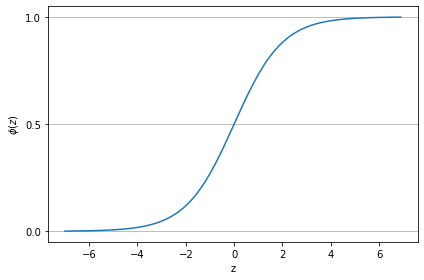

```python
import matplotlib.pyplot as plt
import numpy as np


def sigmoid(z):
    return 1.0 / (1.0 + np.exp(-z))

z = np.arange(-7, 7, 0.1)
phi_z = sigmoid(z)

plt.plot(z, phi_z)
# plt.axvline(0.0, color='k')
# plt.ylim(-0.1, 1.1)
plt.xlabel('z')
plt.ylabel('$\phi (z)$')

# y axis ticks and gridline
plt.yticks([0.0, 0.5, 1.0])
ax = plt.gca()
ax.yaxis.grid(True)

plt.tight_layout()
#plt.savefig('images/03_02.png', dpi=300)
plt.show()
```

## Lost Function

Logistic Regression sử dụng maximize **likelihood** để ước tính được **w**.

Nếu như MSE là phương pháp được sử dụng để ước tính các tham số trong Adaline thì Logistic regression sử dụng maximun likelihood để ước tính tham số w.

- Xét N mẫu dữ liệu được gán nhãn 0 hoặc 1:
  - Với mẫu dữ liệu được gán nhãn 1: chúng ta muốn ước tính tham số W sao cho giá trị đầu ra $\phi{(z)}$ gần với xác suất là 1 nhất có thể.
  - Với mẫu dữ liệu được gán nhãn 0: chúng ta muốn ước tính tham số W sao cho giá trị đầu ra $1 - \phi{(z)}$ gần với xác suất là 1 nhất có thể.
- Tóm lại:
  - Với tất cả mẫu có nhãn 1, chúng ta muốn ước tính $\hat{y}$ sao cho tích của tất cả xác suất có điền kiệu của các mẫu này sao cho gần 1 nhất có thể. Nghĩa là cần maximize $\prod_{ i \in \{y = 1\}} \phi{(z^{(i)})}$ (1)
  - Tương tự với tất cả mẫu có nhãn 0, ta cần maximize $\prod_{ i \in \{y = 0\}} 1 - \phi{(z^{(i)})}$ (2)
- Kết hợp (1) và (2) ta muốn ước tính W sao cho maximize hàm $L(w) = \prod_{ i \in \{y = 1\}} \phi{(z^{(i)})} \times \prod_{ i \in \{y = 0\}} 1 - \phi{(z^{(i)})}$ cho toàn bộ dataset.

$L(w) = \prod_{ i \in \{y = 1\}} \phi{(z^{(i)})} \times \prod_{ i \in \{y = 0\}} 1 - \phi{(z^{(i)})} = \prod_i^n {\phi{(z^{(i)})}}^{y^{(i)}} \times (1 - \phi{(z^{(i)})}) ^{1 - y^{(i)}} $ gọi là **likelihood function**

Trong thực thế, maximize logarit cơ số e của hàm này dễ dàng hơn.

**log-likelihood function**: Ta có:

$$l(w) = \log{L(w)} = log({\phi{(z^{(i)})}}^{y^{(i)}} \times (1 - \phi{(z^{(i)})}) ^{1 - y^{(i)}}) $$$$= log({\phi{(z^{(i)})}}^{y^{(i)}}) \times \log((1 - \phi{(z^{(i)})}) ^{1 - y^{(i)}})$$$$= y^{(i)}\log{({\phi{(z^{(i)})}})} + (1 - y^{(i)})\log{(1 - \phi{(z^{(i)})})}$$

Vì vậy, suy ra được:

$l(w) = \log{L(w)} = \sum_{i = 1}^n [ y^{(i)}\log{({\phi{(z^{(i)})}})} + (1 - y^{(i)})\log{(1 - \phi{(z^{(i)})})}]$

- Sử dụng log để giảm thiểu khả năng xảy ra lỗi *numberical underflow*, có thể xảy ra khi hàm likelihood quá nhỏ $~ 10^{-123}$.
- Log còn dùng để chuyển đổi dấu $\times$ thành $+$ điều này làm cho việc đạo hàm dễ dàng hơn.

Bây giờ có thể sử dụng GD để maximize log-likelihood function hay minimize nó khi viết dưới dạng *cost function* như ở chapter 2: $$J(W) = \sum_{i = 1}^n [- y^{(i)}\log{({\phi{(z^{(i)})}})} - (1 - y^{(i)})\log{(1 - \phi{(z^{(i)})})}]$$

*Cost function* một mẫu dữ liệu: $$J(\phi(z),y;w) = - y\log{({\phi{(z)}})} - (1 - y)\log{(1 - \phi{(z)})}$$

Nhìn vào công thức trên, có thể thấy rằng:

$$j(\phi(z),y;w) = \begin{cases} -\log(\phi(z)) & if &y =1 \\ -\log(1- \phi(z)) & if & y =0 \end{cases}$$

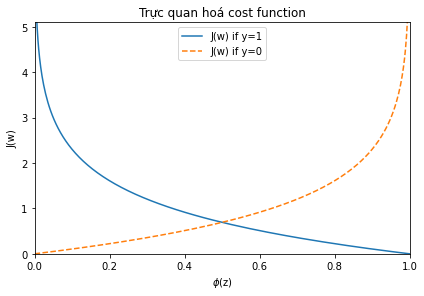

```python
def cost_1(z):
    return - np.log(sigmoid(z))


def cost_0(z):
    return - np.log(1 - sigmoid(z))

z = np.arange(-10, 10, 0.1)
phi_z = sigmoid(z)

c1 = [cost_1(x) for x in z]
plt.plot(phi_z, c1, label='J(w) if y=1')

c0 = [cost_0(x) for x in z]
plt.plot(phi_z, c0, linestyle='--', label='J(w) if y=0')

plt.ylim(0.0, 5.1)
plt.xlim([0, 1])
plt.xlabel('$\phi$(z)')
plt.ylabel('J(w)')
plt.legend(loc='best')
plt.tight_layout()
#plt.savefig('images/03_04.png', dpi=300)
plt.title("Trực quan hoá cost function")
plt.show()
```

## Tính toán GD trongcost function

Để tính toán GD trong cost function của Logistic Regression, ta đạo hàm riêng của hàm chi phí theo w:

$\frac{\partial{i(w)}}{\partial{w}} = -\frac{\partial}{\partial{w}}[ylog(\phi(z)) + (1 - y)log(1 - \phi(z)) ]$

$= -(y\frac{1}{\phi(z)} - (1 - y)\frac{1}{\phi(z)})\frac{\partial}{\partial{w}}\phi(z) $ $(1)$

Ta có: $\frac{\partial}{\partial{w}}\phi(z) = \frac{\partial}{\partial{w}}\frac{1}{1 + e^{-z}}$

$= \frac{e^{-z}}{(1+e^{-z})^2}\frac{\partial}{\partial{w}}z$$=$$\frac{1}{1+e^{-z}} \frac{e^{-z}}{1+e^{-z}} \frac{\partial}{\partial{w}}z $

$= \phi(z)(1 - \frac{1}{1+e^{-z}})\frac{\partial}{\partial{w}}z = \phi(z)(1 - \phi(z))x$$(2)$

Thay (2) vào (1), ta được:

$\frac{\partial{j(w)}}{\partial{w}} = -(y\frac{1}{\phi(z)} - (1-y)\frac{1}{1-\phi(z)} \phi(z)(1 - \phi(z) )x$

$= -[y(1-\phi(z)-(1-y)\phi(z)]x = (y-y\phi(z) - \phi(z) + y\phi(z))x$

$= -(y - \phi(z))x$

Từ đó suy ra đạo hàm riêng của toàn dataset là:

$\frac{\partial}{\partial{W}} = -\sum_{i=1}^n(y^{(i)}-\phi(z^{(i)}))x^{(i)} = \nabla J(W)$

Sử dụng GD, chúng ta có thể update W theo cách đi ngược chiều gradient, $\nabla J(W)$, của cost function $J(W)$:

$$W = W + \Delta W$$

Với $\Delta W = -\eta \nabla J(W) = -\eta[-\sum_{i=1}^n(y^{(i)}-\phi(z^{(i)}) )]$

$= \eta \sum_{i=1}^n(y^{(i)}-\phi(z^{(i)}))$

```python
from sklearn import datasets
import numpy as np

iris = datasets.load_iris()
#2: petal length
#3: petal width
X = iris.data[:, [2, 3]]
y = iris.target
```

```python
from sklearn.model_selection import train_test_split

X_train, X_test, y_train, y_test = train_test_split(
    X, y, test_size=0.3, random_state=1, stratify=y)
```

```python
from sklearn.preprocessing import StandardScaler

sc = StandardScaler()
sc.fit(X_train)
X_train_std = sc.transform(X_train)
X_test_std = sc.transform(X_test)
```

```python
X_combined_std = np.vstack((X_train_std, X_test_std))
y_combined = np.hstack((y_train, y_test))
```

```python
class LogisticRegressionGD(object):
    """Logistic Regression Classifier using gradient descent.

    Parameters
    ------------
    eta : float
      Learning rate (between 0.0 and 1.0)
    n_iter : int
      Passes over the training dataset.
    random_state : int
      Random number generator seed for random weight
      initialization.


    Attributes
    -----------
    w_ : 1d-array
      Weights after fitting.
    cost_ : list
      Logistic cost function value in each epoch.

    """
    def __init__(self, eta=0.05, n_iter=100, random_state=1):
        self.eta = eta
        self.n_iter = n_iter
        self.random_state = random_state

    def fit(self, X, y):
        """ Fit training data.

        Parameters
        ----------
        X : {array-like}, shape = [n_examples, n_features]
          Training vectors, where n_examples is the number of examples and
          n_features is the number of features.
        y : array-like, shape = [n_examples]
          Target values.

        Returns
        -------
        self : object

        """
        rgen = np.random.RandomState(self.random_state)
        self.w_ = rgen.normal(loc=0.0, scale=0.01, size=1 + X.shape[1])
        self.cost_ = []

        for i in range(self.n_iter):
            net_input = self.net_input(X)
            output = self.activation(net_input)
            errors = (y - output)
            self.w_[1:] += self.eta * X.T.dot(errors)
            self.w_[0] += self.eta * errors.sum()

            # note that we compute the logistic `cost` now
            # instead of the sum of squared errors cost
            cost = -y.dot(np.log(output)) - ((1 - y).dot(np.log(1 - output)))
            self.cost_.append(cost)
        return self

    def net_input(self, X):
        """Calculate net input"""
        return np.dot(X, self.w_[1:]) + self.w_[0]

    def activation(self, z):
        """Compute logistic sigmoid activation"""
        return 1. / (1. + np.exp(-np.clip(z, -250, 250)))

    def predict(self, X):
        """Return class label after unit step"""
        return np.where(self.net_input(X) >= 0.0, 1, 0)
        # equivalent to:
        # return np.where(self.activation(self.net_input(X)) >= 0.5, 1, 0)
```

```python
from matplotlib.colors import ListedColormap
import matplotlib.pyplot as plt


def plot_decision_regions(X, y, classifier, test_idx=None, resolution=0.02):

    # setup marker generator and color map
    markers = ('s', 'x', 'o', '^', 'v')
    colors = ('red', 'blue', 'lightgreen', 'gray', 'cyan')
    cmap = ListedColormap(colors[:len(np.unique(y))])

    # plot the decision surface
    x1_min, x1_max = X[:, 0].min() - 1, X[:, 0].max() + 1
    x2_min, x2_max = X[:, 1].min() - 1, X[:, 1].max() + 1
    xx1, xx2 = np.meshgrid(np.arange(x1_min, x1_max, resolution),
                           np.arange(x2_min, x2_max, resolution))
    Z = classifier.predict(np.array([xx1.ravel(), xx2.ravel()]).T)
    Z = Z.reshape(xx1.shape)
    plt.contourf(xx1, xx2, Z, alpha=0.3, cmap=cmap)
    plt.xlim(xx1.min(), xx1.max())
    plt.ylim(xx2.min(), xx2.max())

    for idx, cl in enumerate(np.unique(y)):
        plt.scatter(x=X[y == cl, 0],
                    y=X[y == cl, 1],
                    alpha=0.8,
                    c=colors[idx],
                    marker=markers[idx],
                    label=cl,
                    edgecolor='black')

    # highlight test examples
    if test_idx:
        # plot all examples
        X_test, y_test = X[test_idx, :], y[test_idx]

        plt.scatter(X_test[:, 0],
                    X_test[:, 1],
                    c='',
                    edgecolor='black',
                    alpha=1.0,
                    linewidth=1,
                    marker='o',
                    s=100,
                    label='test set')
```

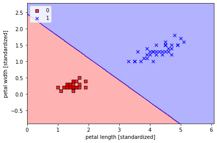

```python
X_train_01_subset = X_train[(y_train == 0) | (y_train == 1)]
y_train_01_subset = y_train[(y_train == 0) | (y_train == 1)]

lrgd = LogisticRegressionGD(eta=0.05, n_iter=1000, random_state=1)
lrgd.fit(X_train_01_subset,
         y_train_01_subset)

plot_decision_regions(X=X_train_01_subset,
                      y=y_train_01_subset,
                      classifier=lrgd)

plt.xlabel('petal length [standardized]')
plt.ylabel('petal width [standardized]')
plt.legend(loc='upper left')

plt.tight_layout()
#plt.savefig('images/03_05.png', dpi=300)
plt.show()
```

## Huấn luyện mô hình logistic regression bằng scikit-learn

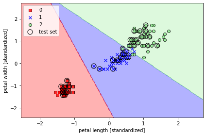

```
Accuracy: 0.978
```

```python
from sklearn.linear_model import LogisticRegression

lr = LogisticRegression(C=100.0, random_state=1, solver='lbfgs', multi_class='ovr')
lr.fit(X_train_std, y_train)

plot_decision_regions(X_combined_std, y_combined,
                      classifier=lr, test_idx=range(105, 150))
plt.xlabel('petal length [standardized]')
plt.ylabel('petal width [standardized]')
plt.legend(loc='upper left')
plt.tight_layout()
# plt.savefig('images/03_06.png', dpi=300)
plt.show()
print('Accuracy: %.3f' % lr.score(X_test_std, y_test))
```

Lưu ý rằng multi_class='multinomial' thường được khuyến nghị trong thực tế cho các lớp "mutually exclusive", như trong ví dụ với Iris dataset. "mutually exclusive" nghĩa là mỗi mẫu dữ liệu chỉ thuộc về một lớp duy nhất (ngược với đa nhãn, một mẫu dữ liệu có thể thuộc về nhiều lớp khác nhau)

Có nhiều thuật toán tối ưu cho việc minimize Cost function. Logistis regression được khuyến khích sử dụng nhiều cách tiếp cận hơn sử dụng GD. Scikit-learn hỗ trợ nhiều thuật toán tối ưu khác nhau thông qua tham số solver: 'newton-cg', 'lbfgs', 'liblinear', 'sag', and 'saga'.

## Xử lý overfitting bằng phương pháp Regularization

Khi một model đưa kết quả training quá tốt (dữ liệu đào tạo) nhưng khi đưa vào dữ liệu test lại không khái quát tốt.  
Lý do:

- Mô hình có phương sai quá cao
- Có quá nhiều tham số khi train  
  $\Rightarrow $ Mô hình quá phức tạp với dữ liệu hiện tại
- Do dữ liệu train bị thiếu  
  $\Rightarrow $ Mô hình không đủ phức tạp để nắm bắt tốt mẫu dữ liệu train $\Rightarrow $ Không thể hiện được dữ liệu test (model có hiệu suất thấp)

Mặc dù chúng ta chỉ mới sử dụng các model tuyến tính để phân loại dữ liệu, các vấn đề về quá mức và thiếu cân bằng có thể được minh họa bằng cách so sánh ranh giới quyết định tuyến tính với các ranh giới phi tuyến phức tạp hơn:

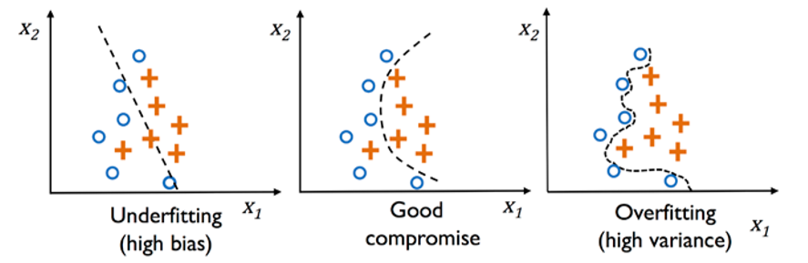

```python
Image(filename ='overfitting.PNG')
```

Thông thường, các nhà nghiên cứu sử dụng thuật ngữ $bias$ và phương sai $variance$ hoặc $bias-variance tradeoff$ để mô tả hiệu suất của một model  
Có nghĩa là: nếu một điểm dữ liệu bị lệch khá nhiều so với các điểm cùng loại  
$\Rightarrow$ độ lệch cao $\Rightarrow$ phương sai cao tỷ lệ thuận với mức quá cao và mức quá cao tỷ lệ thuận với mức thiếu.

Do đó, ta có thể nói rằng model có 1 $high$ $variance$ hoặc 1 $high$ $bias$

Một cách để tìm 1 'good bias-variance trade-off' là điều chỉnh độ phức tạp của model thông qua chính quy hóa (regularization).  
Regularization là 1 phương pháp rất hữu ích để xử lý cộng tuyến (tương quan cao giữa các feature), lọc dữ liệu bị nhiễu và cuối cùng là ngăn chặn overfitting.

Regularization thêm 1 thông tin (bias) để 'trừng phạt' các giá trị tham số cực trị (trọng số).  
Hình thức chính quy hóa phổ biến nhất gọi là chính quy L2 (L2 shrinkage hay weight decay), công thức được viết như sau:

$$\frac{\lambda}{2}||w||^2 = \frac{\lambda}{2}\sum_{j=1}^mw_j^2$$

$\lambda$ được gọi là tham số chính quy hóa (regularization parameter)

Thêm công thức này vào Cost function của Logistic Regression có thể giảm bớt trọng số trong quá trình đào tạo model:

$$J(w) = \sum_{i=1}^n[-y^{(i)}log(\phi(z^{(i)})) - (1 - y^{(i)})log(1 - \phi(z^{(i)}))] + \frac{\lambda}{2}||w||^2$$

Trong đó $\lambda$ gọi là tham số chính quy, $ \lambda = \frac{1}{C}$

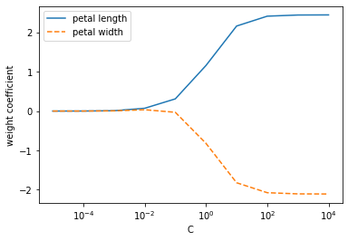

```python
weights, params = [], []
for c in np.arange(-5, 5):
    lr = LogisticRegression(C=10.**c, random_state=1,
                            solver='lbfgs',
                            multi_class='ovr')
    lr.fit(X_train_std, y_train)
    weights.append(lr.coef_[1])
    params.append(10.**c)

weights = np.array(weights)
plt.plot(params, weights[:, 0],
         label='petal length')
plt.plot(params, weights[:, 1], linestyle='--',
         label='petal width')
plt.ylabel('weight coefficient')
plt.xlabel('C')
plt.legend(loc='upper left')
plt.xscale('log')
#plt.savefig('images/03_08.png', dpi=300)
plt.show()
```

Weight hội tụ khi giảm giá trị C